# Introduction to the course

### Introductions

I can start this off. Then we can go around the room, thinking about

- what you want to get out of the course
- how theory fits into your current research (if you are currently doing research)
- any worries/feelings/questions/concerns about the course

### Syllabus

Work through syllabus, clarify structure, discuss final project/Case text/homework structure/paper summaries/etc.

- [syllabus](https://theoreticalEcology.github.io/syllabus/)

### Course website

Go through the course website and make sure everyone has easy access and is clear on how to get the lecture notes, readings, and homeworks.

### Notes

- You may want to [download R](https://www.r-project.org/) as we will be using it to simulate some of the models we go over. However, we will not be learning how to use R during the course (as this would be a bit much to learn at the same time as the theory), but I definitely encourage folks to check out the resources available for working in R, as scientific research tends to need a bit of programming.

### What is theoretical ecology?

**Ecology**: study of species interactions

**Theory**: Body of evidence linking a general explanation to a commonly observed phenomenon

> Theoretical ecology attempts to explain patterns observed in nature through generalized models

### Models

**Statistical model**: A model exploring the statistical relationships between a response and some set of predictor variables. + can be completely independent of theory + can be focused on prediction or variable importance + requires data

e.g., linear regression

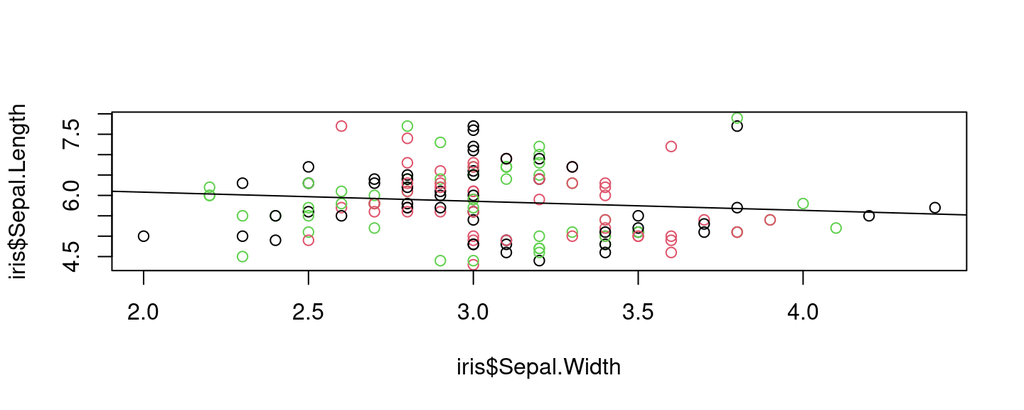

```r
data(iris)
mod <- glm(iris$Sepal.Length ~ iris$Sepal.Width)
plot(iris$Sepal.Length ~ iris$Sepal.Width,
  col=1:3[as.numeric(iris$Species)])
abline(mod)
```

**Phenomenological model**: A model describing some phenomenon, often independent of any data. + an idea of *how* a system behaves given assumptions + incorporates theoretical expectations + incredibly useful when fit or compared to empirical data (where’s the disconnect?)

e.g., exponential growth

### Population dynamics with exponential growth

\[ N_{t+1} = N_t \lambda \]

```r
expoGrowth <- function(n, lambda=1.25, times=100){
  nt <- c(n)
  for(i in 1:times){
    nt[i+1] <- nt[i] * lambda
  }
  return(nt)
}
```

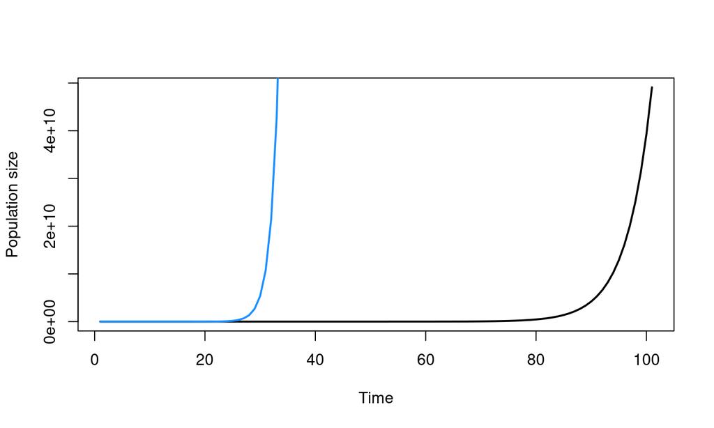

```r
plot(expoGrowth(10), type='l', ylab='Population size',
  xlab='Time', lwd=2)
lines(expoGrowth(10, lambda=2), col='dodgerblue', lwd=2)
```

> This course will focus pretty much entirely on phenomenological models (as I have defined them)

> Also, evolutionary models do not really get emphasized in this book, but this could be good fodder for your paper summaries or final projects if you are interested

### Why theoretical ecology?

- Theory allows us a lens with which to explain natural systems.

**Theory**: which of the cycle-generating processes could cause cycles?

**Generation of novel question**: can models create cycles under processes with different ‘strengths’?

### Why theoretical ecology?

- It provides a useful interface for experimental and observational studies.

**Population model**: Ricker model to explore population dynamics and the role of demographic/environmental stochasticity

**Experiment**: fit models to experimental data and find demographic stochasticity important in controlled laboratory experiments

**Observation**: fit models to empirical time series to explore the relative importance of demographic and environmental stochasticity in natural systems

### Why theoretical ecology?

- It shows us what ecological interactions *could* look like in different conditions

[figure not shown]

### Why theoretical ecology?

- It provides us a concrete way to explore and explain natural processes

[figure not shown]

### Barriers to a more theory-rich discipline

- some ecologists are ‘bad’ at theory. Why? (math/programming/courses)
- Is the world too complex to model? No (most of the time)
  - Is a complex model useful? No (most of the time)

https://www.cell.com/trends/ecology-evolution/fulltext/S0169-5347(19)30171-5

### The promise of theory in ecology

- we have lots of patterns, perhaps more patterns than theory?

> ‘To do science is to search for repeated patterns… The best person to do this [in ecology] is the naturalist who loves to note changes in bird life up a mountainside, or changes in plant life from mainland to island, or changes in butterflies from temperate to tropics’ - Robert MacArthur

*note: I 100% disagree with the assertion that there is a ‘best’ type of ecologist, and that the ‘best’ type would be a naturalist*

### Patterns without theory can be deceiving

[figure not shown]

distribution of birds in Bismarck Archipelago

https://esajournals.onlinelibrary.wiley.com/doi/10.1890/14-1848.1

> Where did Diamond go wrong?

### Theory requires tests

There is an inherent feedback in developing some conceptual theory based on observations, and then testing this theory in different locations or in experimental trials.

[figure not shown]

### Breaking the training divide

[figure not shown]

https://www.cell.com/trends/ecology-evolution/fulltext/S0169-5347(19)30171-5

### So, you’re like a ‘modeler’?

- The ‘modeler’/‘empiricist’ divide is a misnomer and is silly
- The goal of this course is not to pull you away from natural systems, but to give you tools to generalize and explain the dynamics of natural systems

https://royalsocietypublishing.org/doi/10.1098/rsfs.2012.0008

https://www.journals.uchicago.edu/doi/pdfplus/10.1086/717206

### Discussion

> Codling and Dumbrell. 2012. Mathematical and theoretical ecology:linking models with ecological processes. *Interface* doi:10.1098/rsfs.2012.0008

**Note**: + This is an introduction to a special issue organized around ‘Mathematical and theoretical ecology’, so it spends some time trying to tie the papers into a cohesive picture. This is useful for this course, as it gives you an idea of types of theoretical articles.

### The paper was written over a decade ago. In what ways do you think things have changed in the field?

### What were your reactions when you read this?

> “Without ecological theory, collecting data is a futile and meaningless endeavour. Likewise, producing elegantand beautiful mathematical models of ecological systems without validation against real data is an empty achievement”.

### Simplifying assumptions and the mean-field approximation

- The authors discuss (bottom left of page 145) the use of mean-field techniques and sometimes when assumptions used in theoretical models may be alright. This is an important point, because we will make oodles of simplifying assumptions. What are some of the tradeoffs in using simplifying assumptions (both from the article and in your own research)?

### Generating testable predictions

- One role of theory is to generate testable hypotheses. The Rands paper from this issue (discussed on page 147) is a great example. Can we collectively think of other examples of how theoretical models, in the absence of data, have generated testable predictions?

### Lines in the sand

> Broadly speaking, ecological models can be split into two separate categories; simplistic mathematical models, which offer analytically tractable solutions and the examination of the underlying model properties, and more complex simulation-based models (cannot be solved analytically)
- What does it mean to ‘analytically solve’ a model, and how is this useful?
- To what extent has this distinction been eroded in more recent years and why/how?

### Role of stochastic processes

> Ecological systems are very different from physical and chemical systems, notably containing more uncertainty and chaotic dynamics, and are often influenced by stochastic processes.
- This gets at two things
  1. ecological data are messy (imperfect detection etc.)
  2. ecological systems are messy (stochastic birth/death)

To what extent can models incorporate either/or of these processes, allowing theory to easily bridge this data-model divide the authors try to emphasize?

### Ecology in the absence of theory

> After all, without theory providing testable hypotheses, ecology could become nothing more than data collection for its own sake
- The authors are taking a bit of a biased (if not obtuse) view of the field of ecology here (in my opinion). I was curious if this line (towards of the end of article) generated any thoughts from you all.